# Regresión lineal

## 1. Introducción.

En estadística, la regresión lineal es un método estadístico que intenta modelar la relación entre una variable dependiente y una o más variables explicativas. Se denomina regresión lineal simple cuando sólo hay una variable explicativa y regresión lineal múltiple en caso de que hayan dos o más variables explicativas.

La regresión lineal en el contexto de Machine Learning, es un algoritmo de aprendizaje supervisado y es utilizado para predicciones. Sin embargo, no siempre un problema de predicción es un problema clásico de regresión.Por ejemplo, cuando el objetivo es predecir la pertenencia de un conjunto de categorías, ya es un problema de clasificación. Ver [Libro, Dive](https://d2l.ai/d2l-en.pdf)

[figure not shown]

## 2. Breve historia

La palabra *regresión* fue introducida por Francis Galton en el año 1889, a través de la publicación de su libro Natural inheritance, la cual fue constatada por Karl Pearson. Su trabajo constaba en describir la descripción de los rasgos físicos de los hijos (variable dependiente) a partir de los rasgos físicos de sus padres (variable explicativa). Al realizar varios ensayos, Galton observó que los padres muy altos tenian hijos que eran altos, pero que revelaban también una tendencia de regresar a la media.

La primera metodología para regresión lineada fue la de mínimos cuadrados, la cual fue publicada por Legendre en 1805.Diapositiva 3.)

[figure not shown]

## 3. El planteamiento del algortimo.

### Modelo de regresión lineal simple

Primeramente, hay que tener presente que un modelo consta en una representación simplificada de un fénomeno. El modelo tiene dos características principales, las cuales son:

- Debe ser lo más sencillo posible (parsimonia)
- Describa en buena manera al fénomeno y tenga supuestos realistas

Una vez teniendo claro lo anterior, se tiene que un modelo de regresión lineal simple está dado como sigue:

$$y_i=\beta_0+\beta_1x_i+e_i \;\;\; i=1,...,n$$

Donde:

- $y_i$:Variable dependiente o explicada (Variable de interés)
- $x_i$:Variable independiente o explicativa
- $\beta_0 ,\beta_1$: Parámetros
- $e_i$:Error del modelo

Adicionalmente, los errores $e_i$ del modelo de regresión lineal simple debe satisfacer los siguientes supuestos:

- $E(e_i)=0$
- $E(e_i^2)=\sigma^2$
- $E(e_i,e_j)=0$ para todo $i\neq j$
- $e_i \sim$ Normal

### Modelo de regresión lineal múltiple

Ahora, ¿qué pasa si la variable de interés se puede explicar a través de dos o más variables explicativas? Para dar respuesta a la pregunta anterior, existe el modelo de regresión lineal múltiple el cual está dado por la siguiente ecuación

$$ y_i=\beta_0+\beta_1x_{i1}+\beta_2 x_{i2}+\dots+\beta_j x_{ij}+ \dots+\beta_j x_{ik} +e_i \;\;\; i=1,...,n$$

Donde:

- $y_i$: Variable dependiente o explicada
- $x_{ij}$: $j$-ésima variable independiente o explicativa
- $\beta_{j}$: $j$-ésimo parámetro asociado a la j-ésima variable
- $e_i$: Error del modelo
- $k$ es el número de variables explicativas

Como ocurria con la regresión lineal simple, los errores $e_i$ del modelo de regresión lineal múltiple debe satisfacer los siguientes supuestos:

- $E(e_i)=0$
- $E(e_i^2)=\sigma^2$
- $E(e_i,e_j)=0$ para todo $i\neq j$
- $e_i \sim$ Normal

#### Modelo de regresión múltiple expresado en forma matricial

Si se expresa el modelo anterior de forma matricial se obtiene lo siguiente:

$$\begin{pmatrix} y_1\\ y_2\\ \vdots\\ y_n \end{pmatrix} = \begin{pmatrix} 1 & x_{11} & x_{12} & \dots & x_{1k} \\ 1 & x_{21} & x_{22} & \dots & x_{2k}\\ \vdots & \vdots & \vdots & \vdots \\ 1 & x_{n1} & x_{n2} & x_{nk} \end{pmatrix} \begin{pmatrix} \beta_0\\ \beta_1 \\ \vdots\\ \beta_k \end{pmatrix}+ \begin{pmatrix} \epsilon_1\\ \epsilon_2\\ \vdots\\ \epsilon e_n \end{pmatrix}$$

Lo que es equivalente a: $$ Y=X\beta+ \epsilon$$

Y los supuestos quedan experesados de la siguiente forma:

- $E(\epsilon)=0$
- $E(\epsilon\epsilon')=\sigma^2 I$
- $\epsilon$ distribuye normal multivariada
- $E(\epsilon X)=E(\epsilon)E(X)$
- $X$ es rango completo

#### Estimación de los parámetros de una regresión lineal múltiple

Observe que $\epsilon=Y-X\beta$ y por lo tanto:

$$\sum_{i=0}^2 \epsilon_i^n= \epsilon'\epsilon=(Y-X\beta)'(Y-X\beta)$$

Ahora, dados $Y$ y $X$ fijos, hallar $\hat{\beta}$, bajo la filosofía de MCO se convierte en:

$$\text{Minimizar e'e} \Leftrightarrow \text{Minimizar } f(\beta) \Leftrightarrow (Y-X\beta)'(Y-X\beta)$$

Entonces para minimizar $e'e=(Y-X\beta)'(Y-X\beta)$, se tiene en cuenta el cálculo diferencial vectorial, por lo tanto se debe hacer una diferenciación de $e'e$

$$\begin{align} \frac{\partial e'e}{\partial \beta}&= \frac{\partial(Y'Y-\beta'X'Y-Y'X\beta+\beta'X'X\beta)}{\partial\beta} \\ &= \frac{\partial(-2\beta'X'Y+\beta'X'X\beta)}{\partial\beta} \\ &=-2X'Y+2X'X\beta \end{align}$$

Suponiendo que existe $\hat{\beta}$, tal que es punto crítico, entonces:

$\frac{\partial e'e}{\partial \beta}=-2X'Y+2X'X\hat{\beta}=0$

Al despejar $\hat{\beta}$ se obtiene como resultado:

$$\hat{\beta}=(X'X)^{-1}X'Y$$

Se sabe que este valor es mínimo pues

$$\frac{\partial^2 e'e}{\partial \beta^2}=2X'X$$

Y como $X'X$ es una matriz definida positiva entonces un estimador de MCO para el vector $\beta$ está dado por $\hat{\beta}=(X'X)^{-1}X'Y$

Tambien se tiene que la estimación de $Y$ está dada por:

$$\hat{Y}=X\hat{\beta}$$

## 4. Desarrollar un ejemplo de regresión lineal, con datos reales

Se realizará una pequeña aplicación, con unos datos obtenidos de [Kaggle](https://www.kaggle.com/uciml/red-wine-quality-cortez-et-al-2009).

El conjunto de datos consiste en variantes rojas del vino portugués "Vinho Verde".Las variables disponibles son de tipo fisicoquímicas y una sensorial.

Las variables fisicoquímicas son:

- 1 - acidez fija
- 2 - acidez volátil
- 3 - ácido cítrico
- 4 - azúcar residual
- 5 - cloruros
- 6 - dióxido de azufre libre
- 7 - dióxido de azufre total
- 8 - densidad
- 9 - pH
- 10 - sulfatos
- 11 - alcohol

La variable sensorial es:

- 12 - calidad (puntuación entre 0 y 10)

```python
import numpy as np
import pandas as pd
import seaborn as sb
import matplotlib.pyplot as plt
%matplotlib inline
from mpl_toolkits.mplot3d import Axes3D
from matplotlib import cm
plt.rcParams['figure.figsize'] = (16, 9)
from sklearn import linear_model
from sklearn.metrics import mean_squared_error, r2_score
```

```python
#carga de los datos
vino = pd.read_csv('Bases de datos\winequality-red.csv')
#veamos cuantas dimensiones y registros contiene
vino.shape
```

```
(1599, 12)
```

```python
#Por lo anterior se tiene que hay 1599 observaciones y 12 variables
vino.head()
```

|  | fixed acidity | volatile acidity | citric acid | residual sugar | chlorides | free sulfur dioxide | total sulfur dioxide | density | pH | sulphates | alcohol | quality |
| --- | --- | --- | --- | --- | --- | --- | --- | --- | --- | --- | --- | --- |
| 0 | 7.4 | 0.70 | 0.00 | 1.9 | 0.076 | 11.0 | 34.0 | 0.9978 | 3.51 | 0.56 | 9.4 | 5 |
| 1 | 7.8 | 0.88 | 0.00 | 2.6 | 0.098 | 25.0 | 67.0 | 0.9968 | 3.20 | 0.68 | 9.8 | 5 |
| 2 | 7.8 | 0.76 | 0.04 | 2.3 | 0.092 | 15.0 | 54.0 | 0.9970 | 3.26 | 0.65 | 9.8 | 5 |
| 3 | 11.2 | 0.28 | 0.56 | 1.9 | 0.075 | 17.0 | 60.0 | 0.9980 | 3.16 | 0.58 | 9.8 | 6 |
| 4 | 7.4 | 0.70 | 0.00 | 1.9 | 0.076 | 11.0 | 34.0 | 0.9978 | 3.51 | 0.56 | 9.4 | 5 |

No se observan valores faltantes, ahora se realizará un resumen de las variables

```python
vino.describe()
```

|  | fixed acidity | volatile acidity | citric acid | residual sugar | chlorides | free sulfur dioxide | total sulfur dioxide | density | pH | sulphates | alcohol | quality |
| --- | --- | --- | --- | --- | --- | --- | --- | --- | --- | --- | --- | --- |
| count | 1599.000000 | 1599.000000 | 1599.000000 | 1599.000000 | 1599.000000 | 1599.000000 | 1599.000000 | 1599.000000 | 1599.000000 | 1599.000000 | 1599.000000 | 1599.000000 |
| mean | 8.319637 | 0.527821 | 0.270976 | 2.538806 | 0.087467 | 15.874922 | 46.467792 | 0.996747 | 3.311113 | 0.658149 | 10.422983 | 5.636023 |
| std | 1.741096 | 0.179060 | 0.194801 | 1.409928 | 0.047065 | 10.460157 | 32.895324 | 0.001887 | 0.154386 | 0.169507 | 1.065668 | 0.807569 |
| min | 4.600000 | 0.120000 | 0.000000 | 0.900000 | 0.012000 | 1.000000 | 6.000000 | 0.990070 | 2.740000 | 0.330000 | 8.400000 | 3.000000 |
| 25% | 7.100000 | 0.390000 | 0.090000 | 1.900000 | 0.070000 | 7.000000 | 22.000000 | 0.995600 | 3.210000 | 0.550000 | 9.500000 | 5.000000 |
| 50% | 7.900000 | 0.520000 | 0.260000 | 2.200000 | 0.079000 | 14.000000 | 38.000000 | 0.996750 | 3.310000 | 0.620000 | 10.200000 | 6.000000 |
| 75% | 9.200000 | 0.640000 | 0.420000 | 2.600000 | 0.090000 | 21.000000 | 62.000000 | 0.997835 | 3.400000 | 0.730000 | 11.100000 | 6.000000 |
| max | 15.900000 | 1.580000 | 1.000000 | 15.500000 | 0.611000 | 72.000000 | 289.000000 | 1.003690 | 4.010000 | 2.000000 | 14.900000 | 8.000000 |

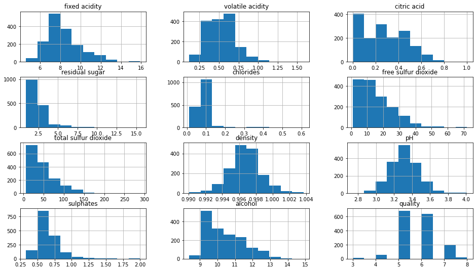

```python
vino.hist()
plt.show()
```

Ahora procederemos con un modelo de regresión simple, donde la variable explicativa es el porcentaje de alcohol.

```python
X=np.asarray(vino['alcohol'])
Y=np.asarray(vino['quality'])


#Regresión lineal:
regl=linear_model.LinearRegression()
regl.fit(X.reshape(-1,1),Y)

#Predicción
y_hat=regl.predict(X.reshape(-1,1))

print('Coeficientes: ', regl.coef_)
print('Valor del intercepto: ', regl.intercept_)
# Error Cuadrado Medio
print("Error cuadrático medio:%.2f" % mean_squared_error(Y,y_hat))
# Puntaje de Varianza. El mejor puntaje es un 1.0
print('Puntaje de varianza: %.2f' % r2_score(Y,y_hat))
```

```
Coeficientes:  [0.36084177]
Valor del intercepto:  1.8749748869971525
Error cuadrático medio:0.50
Puntaje de varianza: 0.23
```

[figure not shown]

```python
plt.scatter(X,Y)
plt.plot(X,y_hat,color='red')
plt.ylabel('%Alcohol')
```

```python
#Se hace una separacion de laas variables
names=list(vino)[0:10]
df=vino[names]
xm=np.array(df)
y_train=vino['alcohol']
```

```python
regm=linear_model.LinearRegression()
regm.fit(xm,y_train)
y_pred=regm.predict(xm)

print('Coeficientes: ', regm.coef_)
print('Valor del intercepto: ', regm.intercept_)
# Error Cuadrado Medio
print("Error cuadrático medio:%.2f" % mean_squared_error(y_train,y_pred))
# Puntaje de Varianza. El mejor puntaje es un 1.0
print('Puntaje de varianza: %.2f' % r2_score(y_train,y_pred))
```

```
Coeficientes:  [ 5.32433095e-01  3.60837746e-01  8.30627496e-01  2.84410582e-01
 -1.46195934e+00 -2.14330209e-03 -2.29579410e-03 -6.17384805e+02
  3.76229342e+00  1.24679232e+00]
Valor del intercepto:  607.2226095182983
Error cuadrático medio:0.37
Puntaje de varianza: 0.67
```